# Rockfish Genomics Reproduction

Gracelyn Hill

11/11/2022

This document is a reproduction of the tree visualization stage of the analysis of the paper “Origins and evolution of extreme life span in Pacific Ocean rockfishes.” I was excited by this paper when I saw it in *Science*, so I thought it would be interesting to reproduce.

A short video was produced to go along with this R markdown script, which you can find here: https://www.youtube.com/watch?v=8C_aW-TSfsk

The paper can be found here: https://pubmed.ncbi.nlm.nih.gov/34762458/ The Sudmant Lab at UC Berkeley, which wrote this paper, was kind enough to include all its scripts in zenodo here: https://zenodo.org/record/5535007#.YVOk9y1h3wo make sure to download this and set your working directory here. The snakefiles and bash scripts necessary to reproduce the paper worked without issue on the GW HPC cluster. However, I chose to focus on this aspect of the paper reproduction because of a possible error I found in the original paper’s data availability.

This is the figure we are attempting to reproduce:

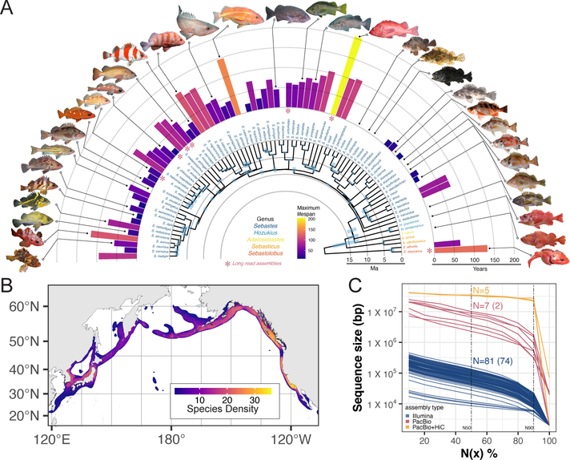

The first step of the analysis is to install and call the required libraries:

```r
#install.packages("tidyverse")

if (!requireNamespace("BiocManager", quietly=TRUE))
  install.packages("BiocManager")

BiocManager::install("ggtree")
BiocManager::install("treeio")
BiocManager::install("ggtreeExtra")
library(tidyverse)
library(ggtree)
library(treeio)
library(ggtreeExtra)
```

The next step is to bring the tree into R and annotate it with labels.

```r
tree <- treeio::read.beast("allspecies_FigTree.20210311.tre")
tree@phylo$tip.label <- gsub("_"," ",tree@phylo$tip.label)
tree@phylo$tip.label <- gsub("Sebastes","S.",tree@phylo$tip.label)
tree@phylo$tip.label <- gsub("dalli","dallii",tree@phylo$tip.label)
tree@phylo$tip.label <- gsub("Hozukius","H.",tree@phylo$tip.label)
tree@phylo$tip.label <- gsub("Adelosebastes","A.",tree@phylo$tip.label)
tree@phylo$tip.label <- gsub("Sebastiscus","S.",tree@phylo$tip.label)
tree@phylo$tip.label <- gsub("Sebastolobus","S.",tree@phylo$tip.label)
```

The step after this would be to annotate the tree with the age ranges of the rockfishes in question.

```r
#lifespan <- read_tsv("max_life_jul5_2020.txt") %>%
 #mutate(shortened_life = case_when(is.na(Max_life) ~ 0,
 #                                   TRUE ~ Max_life/1)) %>%
 # rename(ID=species) %>%
  #mutate(ID = gsub("_", " ",ID)) %>%
#  mutate(ID = gsub("Sebastes","S.",ID)) %>%
 # mutate(ID = gsub("Hozukius","H.",ID)) %>%
#  mutate(ID = gsub("Adelosebastes","A.",ID)) %>%
 # mutate(ID = gsub("Sebastiscus","S.",ID)) %>%
#  mutate(ID = gsub("Sebastolobus","S.",ID)) %>%
#  mutate(ID = gsub("dalli","dallii",ID))
```

That’s because the max_life file doesn’t exist in the zenodo files! Because we don’t know what the format was for this file, we can’t reconstruct the original paper’s pretty graphic. However, let’s try and get as close as we can.

```r
pdf("allspecies_FigTree.20210311.pdf",
    useDingbats = F,
    height=10,width=10)
ggtree(tree, layout="fan",open.angle=180)+
  geom_range(range='height_0.95_HPD', color='#6AADD5', size=2, alpha=.5) +
  geom_tiplab(size=1.5,hjust=-.1,
              align=T,
              linetype = "dotted") +
  #geom_fruit(data=lifespan,
             #geom=geom_bar,
             #mapping=aes(y=ID, x=shortened_life,fill=Max_life),
             #pwidth=1.3,
             #stat="identity",
             #orientation="y",
             #position="auto",
             #offset = 0.44) +
  scale_fill_viridis_c(option="plasma")
dev.off()
```